# Overview

## The task

We want to do something similar to your typical epi chi-squared 2x2, but intead of a 2x2, we have a NxN (n being > 2). This suggests doing a Pearson’s Chi-Squared test Fisher’s exact test (though this is not a straightforward decision unto itself - there is a lot of controversey over which test to use in multiple categories with relatively small counts; see https://stats.stackexchange.com/questions/14226/given-the-power-of-computers-these-days-is-there-ever-a-reason-to-do-a-chi-squa/14230#14230).

## But…

We’re not dealing with “true” categorical data (ie, “sick” vs. “health”, or “male” vs. “female”). Rather, we’ve taken a continuous numeric variable (AFB) and applied cut-points to make them into categories. Once you take contingency tables between the usual 2x2 approach, putting the null and alternative hypotheses into plain English becomes increasinlgy difficult: “there is some kind of relationship between lab A and B”… Also, contingency table approaches treat categories as wholly independent, whereas in reality yours are ordinal.

The two below approaches, I think, would be more principled:

1. **Don’t apply cut points**. Rather, analyze the raw data as is, and compare the distributions using a two-sample Kolmogorov-Smirnov test.
2. **Apply cut points**, but not so many. The more cut-points, the greater the likelihood of a spurious low p-value. For example, in two populations of similar wealth, were cut-points applied at every dollar in wages, they would almost certainly show up as “significantly” different using contingency table approaches, even though a KS test would suggest otherwise. If the cut points don’t have inherent meaning *per se*, it’d be better to reduce the number of them to only meaningful cut-offs (ie, “ill” or “not ill”).

Assuming that you do have access to the raw data (ie, the actual AFB values, rather than their categorical equivalents), my preference would be for number 1.

That said, let’s do the contingency table approach (for now).

# Contingency tables

```r
# Manually enter the data
data <- matrix(c(104,0,17,6,1,0,
                    99,1,35,11,13,2,
                    299,2,196,166,101,13,
                    91,3,115,113,113,10,
                    51,0,68,99,192,42,
                    0,0,0,1,0,0),
                  byrow = TRUE,
                  nrow = 6)
```

## Take a look to make sure our entered data is correct.

```r
print(data)
```

```
     [,1] [,2] [,3] [,4] [,5] [,6]
[1,]  104    0   17    6    1    0
[2,]   99    1   35   11   13    2
[3,]  299    2  196  166  101   13
[4,]   91    3  115  113  113   10
[5,]   51    0   68   99  192   42
[6,]    0    0    0    1    0    0
```

## Chi-squared test

We’re using Pearson’s chi-squared test to see if the distributions is as random, or not. A p-value of less than 0.05 suggests significant differences between the labs.

```r
test <- chisq.test(x = data,
                   simulate.p.value = TRUE,
                   B = 10000)
test
```

```
    Pearson's Chi-squared test with simulated p-value (based on 10000
    replicates)

data:  data
X-squared = 513, df = NA, p-value = 9.999e-05
```

## Fisher’s exact test

We’re testing for the “null independence of rows and columns”.

```r
test <- fisher.test(x = data,
                    hybrid = TRUE,
                    simulate.p.value = TRUE,
                    B = 10000)
test
```

```
    Fisher's Exact Test for Count Data with simulated p-value (based
    on 10000 replicates)

data:  data
p-value = 9.999e-05
alternative hypothesis: two.sided
```

# A better way

Instead of a 2 dimensional contingency table, a better way to deal with these data would be to create two independent vectors of identical length with the lab results. The data would take the following form:

```r
better <- data.frame(id = c(1:10, 1:10),
                     lab = c(rep('A', 10),
                             rep('B', 10)),
                     value = rnorm(mean = 50, n = 20, sd = 30)) %>%
  mutate(value = ifelse(value < 0, 0, value))
print(better)
```

```
   id lab     value
1   1   A  91.56506
2   2   A  68.83618
3   3   A  98.60735
4   4   A 109.92949
5   5   A  56.49724
6   6   A  53.26794
7   7   A   0.00000
8   8   A  68.06514
9   9   A  94.16301
10 10   A  60.62455
11  1   B  46.94728
12  2   B  33.28208
13  3   B  19.71604
14  4   B  17.57860
15  5   B  44.27324
16  6   B  92.91330
17  7   B  17.04042
18  8   B  51.05160
19  9   B  62.72655
20 10   B  22.32077
```

Since we’re now using numeric values, we can compare the distributions…

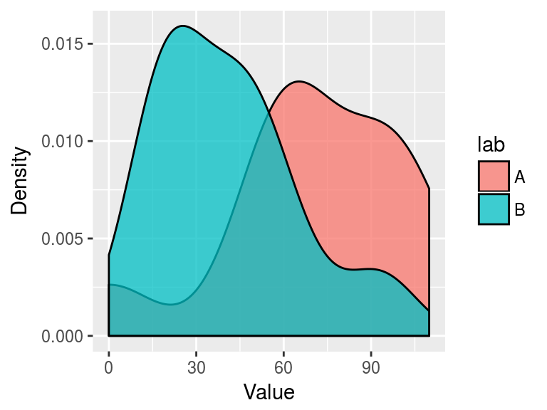

```r
library(ggplot2)
ggplot(data = better,
       aes(x = value,
           group = lab,
           fill = lab)) +
  geom_density(alpha = 0.75) +
  labs(x = 'Value',
       y = 'Density')
```

… and test for sameness of distribution.

```r
ks.test(x = better$value[better$lab == 'A'],
        y = better$value[better$lab == 'B'])
```

```
    Two-sample Kolmogorov-Smirnov test

data:  better$value[better$lab == "A"] and better$value[better$lab == "B"]
D = 0.7, p-value = 0.01234
alternative hypothesis: two-sided
```

# In stata…

- `tabi`, `tabchi` and `tabulate` allow for reporting of Fisher’s and Pearson’s values: https://www.stata.com/statalist/archive/2005-06/msg00052.html / https://www3.nd.edu/~rwilliam/stats1/Categorical-Stata.pdf
- `ksmirnov` handles Kolmogorov-Smirnov testing if you choose to go the “continuous” route (https://www.stata.com/manuals13/rksmirnov.pdf)